# S1_Informe

## Modelo Geométrico - Residencia

Objetivo: Detenerminar la probabilidades hasta obtener un primer exito para la variable residencia en Lima Moderna

Proceso de identificación:

La variable Residencia es una variable aleatoria discreta ya que puede tomar una determinada cantidad de valores numerables. Por lo cual se consideró realizar el modelo de distribución geométrica, para ello se agrupo en 2 categorías para esta variable, tanto en éxito y fracaso. De los cuales tenemos:

Éxito: La persona resida en Lima Moderna Fracaso: {Callao, Lima antigua, Lima este, Lima norte y Lima Sur}

- Debido que presenta un comportamiento de distribución geométrico presenta los siguinetes parámetros:

p = Probabilidad de éxito para cada enayo

```r
GeoResidencia <- Encuesta %>% filter(Residencia == "Lima moderna")
(p = nrow(GeoResidencia)/nrow(Encuesta))
```

```
## [1] 0.4215686
```

p= 0.42156863 = 0.4215

X: N° de personas pertenecientes a Lima Moderna

Del cual su rango estará definido por: Rx = {0,1,2,3,4,…,k}

A partir de ello podemos establecer el *Modelo geométrico*:

X~G(0.4215)

- Gráfica de función de probabilidad para los residentes en Lima Moderna:

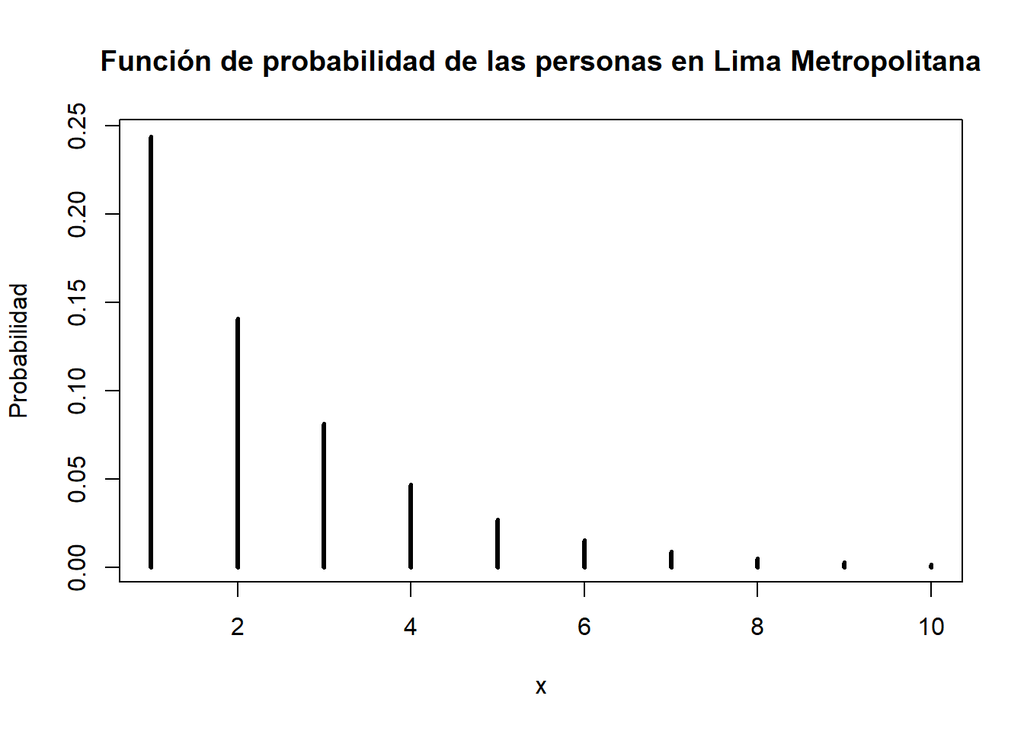

```r
plot(dgeom(x=1:10,prob=0.4215),lwd=3,type='h', xlab='x', ylab='Probabilidad', main = "Función de probabilidad de las personas en Lima Metropolitana")
```

1. ¿Cuál es la probabilidad de que se obtenga el primer residente de Lima Moderna en la quinta prueba?

G(X=5) = 0.0472075

```r
dgeom(4,0.4215)
```

```
## [1] 0.0472075
```

2. ¿Cuál es el valor esperado del número personas residentes en Lima Moderna?

Esperanza = 1/p = 2

```r
(Ex3 = 1/0.4215)
```

```
## [1] 2.372479
```

- Resultado Obtenidos: